# In-class exercise for week 3-2

1. conditional statements & try except statements
2. function

## Function

A function groups together instructions and gives them a name. They are the most important way to reuse code. Python functions are named after functions in math and, just like their mathematical counterparts, have inputs and outputs. Functions begin with the def keyword.

1) Customerized functions

2) Python built in function

3) Libraries' function

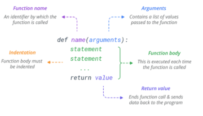

### 1. Customized functions

### 1-1. Indentation

The statements inside of a function must be ligned up to the right of the function and even with each other.

You can use either tabs (indentation) but you can't mix them. Use of indentations in Python is designed to help you easily see the instructions that are inside and oustide of a function.

```
def line_up():
    print('This is inside')
    print('Also inside')
print('This is outside')
print('Still outside')
```

Indentations (Whitespace) in Python enforces a readable style. Not everyone likes that.

```python
def line_up():
    print('This is inside')
    print('Also inside')
print('This is outside')
print('Still outside')
```

```
This is outside
Still outside
```

### 1-2. Parameter (argument)

Funtions are like machines that take inputs and produce outputs. The input to the function is called an parameter/argument and the output is called a return value.

Function parameters are named in the function definition between the parentheses, they are separated by commas.

Here's an example of a function that takes one parameter:

```python
def say_hello(name):
    print('hello',name)
```

Let's call `say_hello` with a parameter (your name)

```python
say_hello('Vinay')
```

```
hello Vinay
```

Let's make an example of a function that takes two parameters:

```python
def introduction(first_name,last_name):
    print('hello',first_name,last_name)
```

```python
introduction('Vinay','Karthick')
```

```
hello Vinay Karthick
```

#### Default parameters

If we call the function without argument, it uses the default value.

```python
def my_country(country='United States'):
    print("I am from",country)
```

```python
my_country()
```

```
I am from United States
```

```python
my_country('Canada')
```

```
I am from Canada
```

### 1-3.Return values

Most functions both take parameters and return values.

Return is not required to create a function but recommended to close a function (showing returning a result to a function)

If you don't include `return` the defult is `return None` which means doing nothing.

Like parameters, return values can be more than one and seperated by comma.

```python
def test_function(x):
    return 5*x
```

```python
test_function(6)
```

```
30
```

```python
def what():
    print('?')
    return None
```

```python
what()
```

```
?
```

```python
def what():
    return '?'
```

```python
what()
```

```
'?'
```

### 1-4. Function Variables and Scope

Variables created inside of a function, including the function paramesters, are *private* or `local` to the function.

That means they only exist while the funciton is executing and disappear after the function returns.

For beginners this can be confusing, but it's an essential feature of Python and other programming languages. The validity of a variable is called *scope*.

When you use a global variable inside of a function Python has to make a guess.

Should I use the global variable or should I create a local variable?

Python will always choose to make a local variable. The `global` keyword tells Python to use the global variable rather than create a new local one.

```python
a=7
```

```python
print(a)
```

```
7
```

```python
def access_local(a):
    print("a printed from local",a)
```

```python
access_local(3)
```

```
a printed from local 3
```

#### Avoid Global Variables

Sometimes global variables are necessary but unless there's no other way to do something it's a good idea to avoid global variables. Global variables make programs harder to read and can lead to confusing problems.

### WARNING: Functions in Functions

In Python it's posible to define a function *inside* of another function. **DO NOT DEFINE A FUNCTION INSIDE OF ANOTHER FUNCTION** unless you know what you're doing. All of your functions should begin all the way to the left of the page.

#### Question1

Step 1: Write a function called `rectangle` to calculate a rectangle area.

1) name: rectangle

2) parameter: width, length

4) return: width* lengh

Step 2: call `rectangle` with parameters: width=2, lengh=3.

```python
def rectangle(width,length):
    return(width*length)
```

```python
rectangle(2,3)
```

```
6
```

#### Question2

Step 1: Write a function called `print_repeat` that takes two parameters, words and times. The function prints words times times.

1) name: print_repeat

2) parameter: words (string) - The words to repeat times (integer) - Another number

3) Returns: None

step 2: call `print_repeat` with parameters: words is "I love learning Python!" and times is 2.

```python
def print_repeat(word,time):
    return (word*time)
```

```python
print_repeat("I love Python!",2)
```

```
'I love Python!I love Python!'
```

### 2. Python built-in functions

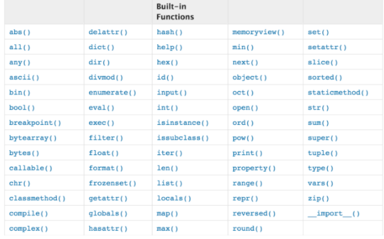

https://docs.python.org/3/library/functions.html

#### Exercise 1

Here are some examples.

1) round (number, digits): returns a floating point number that is a rounded version of the specified number, with the specified number of decimals.

2) len (value): It will return an integer value i.e. the length of the given string, or array, or list or collections.

```python
a=6.7893
```

```python
print(round(a,2))
```

[output not shown]

#### Question3 - Do it at home!

Step 1) go to the following webpage: https://docs.python.org/3/library/functions.html

Step 2) explore various Python built-in functions and try TWO functions other than `round` and `len`.

```python
bin(3)
```

```
'0b11'
```

```python
bool(5)
```

```
True
```

### 3. Functions from libraries

We can also use functions created by other programmers.

To use libraries/packages created by other programmers, you need to import your interested library first.

```python
import math
```

```python
math.factorial(6)
```

```
720
```

```python
math.fabs(7.543)
```

```
7.543
```

#### Question4 - Do it at home!

Step 1) go to the following webpage: https://docs.python.org/3/library/math.html

step 2) explore various functions offered by Math library and show TWO examples using the library, Math's functions.

**Note: Since you already import the math library, you don't need to re-import the library as long as you don't start the new environment(shutting down Jupyter notebook/the kernel).

```python
x=5.6
```

```python
math.floor(x)
```

```
5
```

```python
Y=int(5)
```

```python
math.factorial(Y)
```

```
120
```

#### Question 5 - Do it at home!

Step 1) create your own function naming "my_function" which should include

- at least one parameter
- the try statement (try, except, and else)
- either the python built-in function or the math function

Other than those three requirements, create one as you want!

step 2) invoke your function with one example.

```python
def my_function(age):
    try:
        if 25<age<75:
            print('ticket cost is $10')
        else:
            print("free entry")
    except:
        print ('check your number')
    else:
        print('done')
```

```python
my_function(30)
```

```
ticket cost is $10
done
```